# Introduction to R and Rstudio

[figure not shown]

## What is the R programming language?

Although R is technically a programming language, it was developed specifically for analyzing data. We will therefore teach R in the context of analyzing data rather than as one would teach a programming language. As a result, we will be learning some data analysis concepts along the way.

For anyone with limited programming experience, here are some useful R programming courses to help you getting started with R:

- DataCamp’s [R course](https://www.datacamp.com/courses/free-introduction-to-r)
- edX’s [Introduction to R Programming](https://www.edx.org/course/introduction-r-programming-microsoft-dat204x-0)

Below we include a broader list of resources for learning R.

## Installing R

The first step is to install R. You can download and install R from the [Comprehensive R Archive Network](https://cran.r-project.org/) (CRAN). It is relatively straightforward, but if you need further help you can try the following resources:

- [Installing R on Windows](https://github.com/genomicsclass/windows#installing-r)
- [Installing R on Mac](http://youtu.be/Icawuhf0Yqo)
- [Installing R on Ubuntu](http://cran.r-project.org/bin/linux/ubuntu/README)

## Installing RStudio

The next step is to install [RStudio](https://www.rstudio.com/home/), a program for viewing and running R scripts. Technically you can run all the code shown here without installing RStudio, but we highly recommend this integrated development environment (IDE). Instructions are [here](http://www.rstudio.com/products/rstudio/download/) and for Windows we have special [instructions](https://github.com/genomicsclass/windows).

RStudio is especially useful because it includes a console, syntax-highlighting editor and tools for plotting, history, debugging and workspace management.

## The R Console

Now that you have download and installed R you are ready to start working with data. Whichever approach you are using to interact with R, we recommend RStudio, you should identify the console.

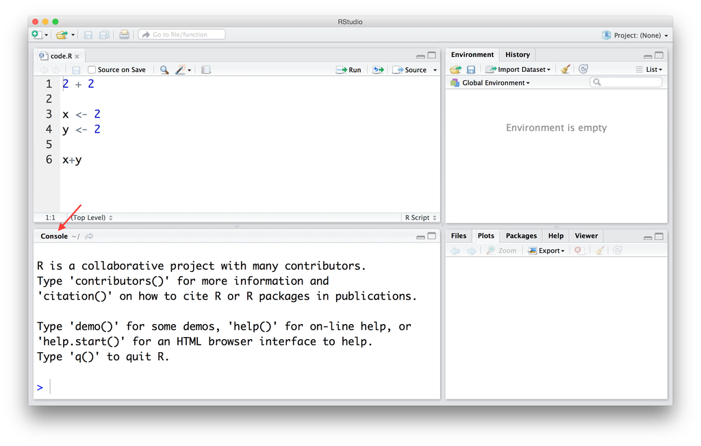

#### Your turn

Open the R Markdown file (ends in `.Rmd` in RStudio). If you have successfully installed R and RStudio, you should be able to follow along with the rest of this tutorial by running code yourself.

When you type a line of code into the console and hit enter the command gets *executed*. For example, try typing:

```r
2+2
```

```
## [1] 4
```

We can also assign values to variables. Try the following

```r
x <- 2
y <- 2
x + y
```

```
## [1] 4
```

## The R ecosystem

When you download R from [CRAN](https://cran.r-project.org) you get what we call *base* R. This includes several *functions* that are considered fundamental for data analysis. It also includes several example datasets. These datasets are particularly useful as examples when we are learning to use the available functions. You can see all the available dataset by executing the function `data()` like this:

```r
data()
```

Because in R functions are objects, we need the two parenthesis to let R know that we want the function to be executed as opposed to showing us the code for the function. Type the following and note the difference:

```r
data
```

#### Explore a data set in R

To see an example of functions at work, we will use the `faithful` dataset (Old Faithful Geyser Data). To view any data set that has been loaded in R, you can just type the name of the data set. Be careful if you have a large data set as this will print all rows and all columns in the R console.

```r
faithful
```

We see there are two columns titled `eruptions` and `waiting` and 272 observations.

Alternatively, if you want to see just the first few rows of the data set, use the `head()` (or `tail()`) function, which returns the first few (or last) rows.

```r
head(faithful)
```

```
##   eruptions waiting
## 1     3.600      79
## 2     1.800      54
## 3     3.333      74
## 4     2.283      62
## 5     4.533      85
## 6     2.883      55
```

```r
tail(faithful)
```

```
##     eruptions waiting
## 267     4.750      75
## 268     4.117      81
## 269     2.150      46
## 270     4.417      90
## 271     1.817      46
## 272     4.467      74
```

If you want to see a summary of the structure (or dimension) of the data set, you can use the `str()` (or `dim()`) function.

```r
str(faithful)
```

```
## 'data.frame':    272 obs. of  2 variables:
##  $ eruptions: num  3.6 1.8 3.33 2.28 4.53 ...
##  $ waiting  : num  79 54 74 62 85 55 88 85 51 85 ...
```

```r
dim(faithful)
```

```
## [1] 272   2
```

Here we see that this object is a `data.frame`. These are one of the most widely used data types in R. They are particularly useful for storing tables.

Finally, you can use the `View()` function to open a “spreadsheet-style” data viewer of the data set.

```r
View(faithful)
```

#### Extracting elements in a data frame

To extract specific elements in a `data.frame` in R, we can use the `[` symbol:

```r
## extract element in 5th row and 2nd column
faithful[5,2]
```

```
## [1] 85
```

```r
## extract element in 10th row and 1st column
faithful[10,1]
```

```
## [1] 4.35
```

#### Extracting entire columns

There are two ways to extract an entire column from a `data.frame`.

The first way is to use the `[` symbol:

```r
faithful[,1]
```

Note, we do not write a number before the comma, which tells R to return all the rows in the first column. This returns a vector.

Alternatively, to extract columns by specifying the name of the column in the `data.frame` we use the `$` character like this:

```r
faithful$eruptions
```

This also returns a vector.

To return a list of the column names, we use the `colnames()` function

```r
colnames(faithful)
```

```
## [1] "eruptions" "waiting"
```

Finally, we access elements from a vector using the `[` symbol:

```r
faithful$eruptions[2]
```

```
## [1] 1.8
```

#### Quick Review of Vectors

Vector are a sequence of data elements of the same type. Many of the operations used to analyze data are applied to vectors. In R vectors can be numeric, characters or logical.

The most basic way to create a vector is with the function `c()`

```r
x <- c(1,2,3,4,5)
```

Two very common ways of generating vectors are using `:` (called the colon operator) or the `seq()` function:

```r
x <- 1:5
x
```

```
## [1] 1 2 3 4 5
```

```r
x <- seq(1,5)
x
```

```
## [1] 1 2 3 4 5
```

Vectors can have names

```r
names(x) <- letters[1:5]
x
```

```
## a b c d e
## 1 2 3 4 5
```

#### Coercion

Vectors need to be homogenous. But when R is instructed to create a vector of different types, it does not give an error. Instead it tries to *coerce* values to be the same. Here is an example of coercing a list of numbers (heights in inches) with a character string (height in feet and inches):

```r
height <- c(60, 59, 55, "5'5", 70)
height
```

```
## [1] "60"  "59"  "55"  "5'5" "70"
```

Note that no warning or error was given. It simply changed everything to a character. This is important to know because sometimes we make a mistake in entering data and receive no error message.

#### Using a base function in R

To illustrate the function `plot()` (one of the base functions in R), we can plot the “eruption time” and “waiting time to next eruption” like this:

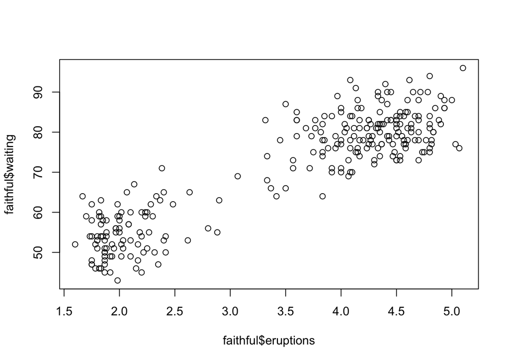

```r
plot(x = faithful$eruptions, y = faithful$waiting)
```

## Getting help

A key feature you need to know about R is that you can get help for a function using `help` or `?`, like this:

```r
?plot
help("plot")
```

These pages are quite detailed and also include examples at the end.

#### Your turn

Add labels to the x and y axes. Use the help file to read about how to do that.

```r
## Provide your code here
```

Generally speaking, R’s base functionality is bare bones. In reality, applications of statistics and data analysis can be quite broad. Therefore, the statistical toolbox developed by R developers and users is extensive. Most users need only a small fraction of all the available functionality. Therefore, a better approach is to make specific functionality available *on demand*. R does this using *packages*, also called *libraries*.

Some packages are considered popular enough that they are included with the base download. For example, the software implementing the method of survival analysis are in the `survival` package. To bring that those functions in the `survival` R package to your current R session we type:

```r
library(survival)
```

However, CRAN has over 4,000 packages that are not included in the base installation. You can install these using the `install.packages()` function.

## Installing Packages

The first R command we will run is `install.packages()`. R only includes a basic set of functions. It can do much more than this, but not everybody needs everything so we instead make some functions available via packages. Many of these functions are stored in CRAN where packages are vetted: they are checked for common errors and they must have a dedicated maintainer. There are other repositories, some with more vetting, such as [Bioconductor](http://www.bioconductor.org), and no vetting, such as GitHub. You can easily install CRAN packages from within R if you know the name of the packages. As an example, we are going to install the package `dplyr` which we use in our first data analysis examples:

```r
install.packages("dplyr")
```

We will learn about the `dplyr` R package later on today. For now, all we need to know is that we can then load the package into our R session using the `library` function:

```r
library(dplyr)
```

From now on you will see that we sometimes load packages without installing them. This is because once you install the package, it remains in place and only needs to be loaded with `library`. If you try to load a package and get an error, it probably means you need to install it first.

## Comments

The hash character represents comments, so text following these characters is not interpreted:

```r
##This is just a comment
##Note the comment is inside of the three "ticks" on the top and bottom
##The "ticks" tell R this is a code chunk.
##Anything inside of a code chunk be evaulated, unless it is commented out
```

## Paths and the Working Directory

When you are working in R it is useful to know your *working directory*. This is the directory or folder in which R will save or look for files by default. You can see your working directory by typing:

```r
getwd()
```

You can also change your working directory using the function `setwd()`. Or you can change it through RStudio by clicking on “Session” in the top menu bar.

The functions that read and write files (there are several in R) assume you mean to look for files or write files in the working directory. Our recommended approach for beginners will have you reading and writing to the working directory. However, you can also type the [full path](http://www.computerhope.com/jargon/a/absopath.htm), which will work independently of the working directory.

## Projects in RStudio

We find that the simplest way to organize yourself is to start a Project in RStudio

#### Your turn

In the top menu bar, click on “File” and “New Project”. When creating the project, you will select a folder to be associated with it. You can then download all your data into this folder. Your working directory will be this folder.

## Resources

Apart from the two courses lister above, there are many resources to help you familiarize yourself with the basics of programming and R syntax. One such tutorial is the [swirl](http://swirlstats.com/) tutorial, which teaches you R programming interactively, at your own pace and in the R console. Once you have R installed, you can install `swirl` and run it the following way:

```r
install.packages("swirl")
library(swirl)
swirl()
```

[try R](http://tryr.codeschool.com/) interactive class from Code School.

There are also many open and free resources and reference guides for R. Two examples are:

- [Quick-R](http://www.statmethods.net/): a quick online reference for data input, basic statistics and plots
- R reference card [PDF](https://cran.r-project.org/doc/contrib/Short-refcard.pdf) by Tom Short

#### More advanced R Resources (from Roger Peng)

Available from CRAN (http://cran.r-project.org)

- An Introduction to R
- Writing R Extensions
- R Data Import/Export
- R Installation and Administration (mostly for building R from sources)
- R Internals (not for the faint of heart)

#### Some Useful Books on R

Standard texts

- Chambers (2008). *Software for Data Analysis*, Springer.
- Chambers (1998). *Programming with Data*, Springer.
- Murrell (2005). *R Graphics*, Chapman & Hall/CRC Press.

Other resources

- Springer has a series of books called *Use R!*.
- A longer list of books is at http://www.r-project.org/doc/bib/R-books.html